# Лабораторная работа № 4.

## Газовый цилиндрический счётчик.

### Кафедра физики ускорителей

Вероника Бояркина, Вячеслав Федоров, Анна Шуклина

## Теория

В данной работе исследуется газовый цилиндрический счетчик, состоящий из металличе- ского цилиндрического катода диаметром 20 мм и анодной проволочки диаметром 0.05 мм, расположенной на оси цилиндра. Пространство между катодом и анодом заполнено газо- вой смесью при атмосферном давлении, состоящей обычно из благородного газа (аргон, неон, криптон) и многоатомной органической добавки (изобутан, метан, эфир, н-пентан и т.д.). Между катодом и анодом создается разность потенциалов, величина которой вы- бирается в зависимости от режима работы счетчика: ионизационная камера, пропорцио- нальный, стримерный, Гейгера–Мюллера, искровой.

Между катодом и анодом создается разность потенциалов, величина которой вы- бирается в зависимости от режима работы счетчика: ионизационная камера, пропорцио- нальный, стримерный, Гейгера–Мюллера, искровой. На рис. 4.1 приведена зависимость тока с анодной проволочки от приложенного напря- жения при облучении счетчика α-частицами и электронами. В области I электроны и ионы первичной ионизации успевают частично рекомбинировать за время дрейфа в зазоре меж- ду катодом и анодом. При увеличении разности потенциалов вероятность рекомбинации уменьшается, что приводит к росту тока. Область I называют областью рекомбинации. В области II процессами рекомбинации можно пренебречь и вся первичная ионизация доходит до электродов, и ток с анодной проволочки не меняется. В этом диапазоне на- пряжений цилиндрический счетчик работает в режиме ионизационной камеры. В области IIIa начинается процесс газового усиления [1]. В результате этого ток с анодной прово- лочки начинает экспоненциально возрастать в зависимости от напряжения на счетчике, при этом сигнал с анодной проволочки пропорционален величине первичной ионизации. В области ограниченной пропорциональности IIIb пропорциональность нарушается из-за пространственного заряда вблизи анодной проволочки. Далее, в зависимости от соста- ва газа, используемого в счетчике, возможны два режима работы. В первом случае из области ограниченной пропорциональности счетчик плавно переходит в режим Гейгера- Мюллера (IV), при этом сигнал с анодной проволочки не зависит от величины первичной ионизации. Указанием на начало области Гейгера-Мюллера можно считать то обстоятель- ство, что величина импульса для частиц с разной ионизирующей способностью, таких как α- и β-частицы, становится одинаковой. Во втором случае при увеличении напряжения наблюдается скачкообразное увеличение амплитуды сигнала с анодной проволочки и его дальнейший экспоненциальный рост. При этом зависимость амплитуды сигнала с анодной проволочки от величины первичной ионизации и типа частицы исчезает. Этот режим на- зывается стримерным — область V. При дальнейшем увеличении напряжения в счетчике загорается разряд или происходит искровой пробой — область VI.

[figure not shown]

## Описание работы

### Используемое оборудование

В работе используются модули электроники в стандарте КАМАК производства ИЯФ СО РАН. Управление электроникой и считывание информации происходит с помощью компьютера. С помощью аттенюатора можно управлять амплитудой сигнала после предусилителя, ослабляя его на заданное количество децибел с шагом 3 дБ. Максимальное ослабление одного аттенюатора составляет 45 дБ. Это нужно для согласования амплитуды сигна- ла с динамическим диапазоном ЗЦП.

Блок ЗИФ имеет два канала, из которых используется один в качестве формирователя логических импульсов. Блок служит для формирования управляющего сигнала ЗЦП, в течение которого ЗЦП интегрирует входной сигнал. При запуске управляющей программы длительность управляющего импульса устанавливаеся в подходящее значение. В работе также имеется осциллограф, с помощью которого можно наблюдать сигнал со счётчика.

### Программное обеспечение

Для управления электроникой используется специальная программа, написанная на ос- нове среды для анализа физических данных ROOT [3]. Она позволяет управлять всеми блоками КАМАК с помощью наглядного графического пользовательского интерфейса (ГПИ), набирать гистограмму амплитудного распределения с ЗЦП и анализировать ее, используя стандартные средства ГПИ ROOT.

В окне прямоугольника- ми изображены интерфейсы управления блоками КАМАК. Относительный размер и рас- положение прямоугольников соответствует позиции и ширине соответствующих блоков электроники в крейте КАМАК. Кроме того, многоканальные блоки имеют интерфейсы управления каналами, которые графически расположены в соответствии с физическим расположением каналов на лицевой панели блоков. Интерактивные элементы ГПИ стан- дартны и включают: кнопки, радиокнопки, переключатели и текстовые поля. Управление программой требует базовых навыков работы с графическими интерфейсами.

## Задания

1900 V

[figure not shown]

2100 V

[figure not shown]

[figure not shown]

2300 V

[figure not shown]

2300 V (включили делитель)

[figure not shown]

2400 V (включили делитель)

[figure not shown]

2500 V (включили делитель)

[figure not shown]

2600 V (включили делитель)

[figure not shown]

2700 V (включили делитель)

[figure not shown]

Для каждого значения напряжения:

- Определить амплитуду основного пика
- Определить полную ширину пика на его полувысоте..

```python
import pandas as pd
```

```python
columns = ['voltage', 'first_mean', 'second_mean', 'first_width', 'second_width',  'attenuation', 'divider']
data_df = pd.DataFrame([[1900, 382, 382, 110, 110, 3, False],
                  [2000, 329, 858, 100, 200, 3, False],
                  [2100, 300, 950, 200, 200, 3, False],
                  [2300, 230, 1200,  100, 400,  3, False],
                  [2300, 330, 1600, 100, 600, 3, True],
                  [2400, 370, 2480, 500, 900, 3, True],
                  [2500, 220, 1250, 100, 300, 3, True],
                  [2600, 190, 1500, 100, 400, 3, True],
                  [2700, 180, 960, 70, 600, 3, True]],
                  columns=columns)
```

2. Для каждого установки ослабления аттенюатора откалибровать положение пьеде- стала ЗЦП, отсоединив выход A блока TA от входа аттенюатора (радиоизотоп дол- жен находится на трубке). Центр тяжести спектра даст значение, соответствующую пьедесталу. Положение пьедестала должно учитываться при обработке всех ампли- тудных спектров.

[figure not shown]

```python
pedestal = 140

data_df['first_mean'] = data_df['first_mean'] - pedestal
data_df['second_mean'] = data_df['second_mean'] - pedestal
```

2000 V (включили делитель) 9 db

[figure not shown]

2700 V (включили делитель) 21 db

[figure not shown]

## Обработка и представление результатов

1. Для отчета выборочно распечатать амплитудные спектры иллюстрирующие пропор- циональный и стримерный режимы, а также переход из одного в другой

См. выше.

2. Используя пик, возникший от поглощения 6-кэвного гамма кванта изотопа 55Fe, по- строить в логарифмическом масштабе в произвольных единицах зависимость коэф- фициента газового усиления от напряжения. Точки пропорционального и стример- ного режимов отложить на одном графике.

```python
data_df['first_amplitude'] = data_df['first_mean'] / 10**(-data_df['attenuation']/20)
data_df['second_amplitude'] = data_df['second_mean'] / 10**(-data_df['attenuation']/20)
```

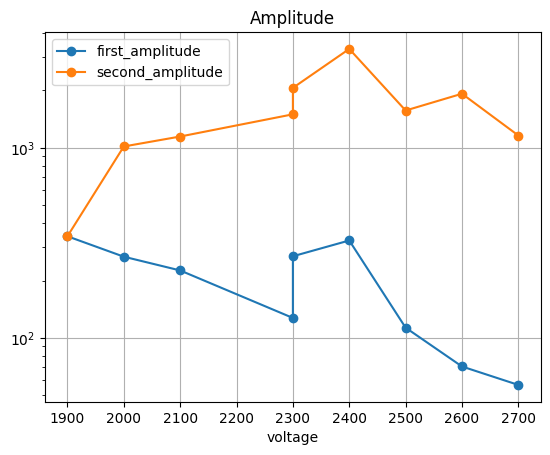

```python
import matplotlib.pyplot as plt

data_df.plot(x='voltage', y=['first_amplitude', 'second_amplitude'], logy=True, title='Amplitude', grid=True, kind='line', marker='o')
```

3. Построить зависимость амплитудного разрешения счетчика ∆A/A от напряжения для пропорционального и стримерного режимов на одном графике. ∆A — ширина пика на полувысоте, A — среднее значение амплитуды.

```python
data_df['first_resolution'] = data_df['first_width'] / data_df['first_mean']
data_df['second_resolution'] = data_df['second_width'] / data_df['second_mean']
```

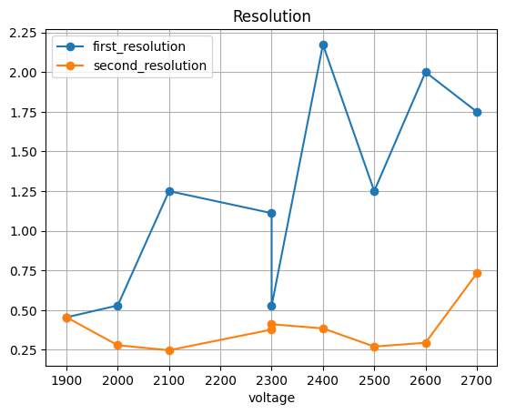

```python
data_df.plot(x='voltage', y=['first_resolution', 'second_resolution'], title='Resolution', grid=True, kind='line', marker='o')
```

4. Дать объяснение изменению амплитудных спектров в зависимости от напряжения.

См. теорию

5. Ответить на контрольные вопросы.

См. ниже.

## Вопросы

### Механизм образования, дрейфа и усиления ионизации в газовом цилиндрическом счетчике.

см. теорию

### Особенности разных режимов работы газового цилиндрического счетчика.

см. теорию

### Почему отличаются формы импульсов при облучении изотопами 55Fe и 90Sr?

Различие в формах импульсов, получаемых при облучении счетчика изотопами 55Fe и 90Sr, объясняется различиями в типах излучаемых частиц и их энергетических характеристиках.

Разница в формах импульсов связана не только с амплитудой, но и со скоростью нарастания и спада импульса, которые зависят от взаимодействия излучаемых частиц с газом в счетчике. Бета-частицы, имея большую энергию, могут пройти через газ на большее расстояние, создавая по пути больше ионов, что приводит к формированию импульсов с более выраженной амплитудой и другим временем нарастания/спада по сравнению с импульсами от низкоэнергетических частиц.

### Чем определяется длительность переднего и заднего фронта импульса со счётчика в пропорциональном режиме?

Длительность переднего и заднего фронта импульса со счетчика в пропорциональном режиме определяется несколькими факторами, связанными как с физическими процессами внутри счетчика, так и с характеристиками электронной схемы, используемой для регистрации сигналов. Вот основные из них:

1. Процесс дрейфа ионов и электронов. В пропорциональном счетчике после первичного ионизирующего события образуются электроны и ионы. Электроны движутся к аноду, а ионы - к катоду. Скорость дрейфа этих заряженных частиц зависит от их подвижности и напряженности электрического поля внутри счетчика. Более высокое напряжение увеличивает скорость дрейфа, что может уменьшать длительность переднего фронта импульса.
2. Процесс умножения заряда. Время, необходимое для развития этого процесса, также влияет на длительность переднего фронта.
3. Геометрия и размеры счетчика. Большие размеры счетчика могут увеличивать время дрейфа заряженных частиц к электродам, что влияет на длительность импульсов.
4. Свойства газа. Тип газа и его давление внутри счетчика влияют на подвижность заряженных частиц и скорость развития процесса умножения заряда, что может изменять форму импульса.
5. Характеристики электронной схемы..